# VerityRefiner Job Results: Import

```
job result file:  IRS_Migration_1_analysis_20240201T094532.dat
```

### Introduction

This Notebook imports data from a VerityRefiner job results export file. This file has a special structure to allow importing it into a variety of analysis tools, including MicroSoft Excel and Jupyter Notebook. However, the import must be done knowing the detailed file structure and what each section means and should be presented. Technik Interlytics provides information on the file structure, how to export it, and how to import it in its help guide.

This Notebook uses the export from a sample job and creates Python objects for each of the major results components. It then uses these objects to filter into DataFrames to generate many tables and figures showing the result data. These roughly correspond to how results are shown in VerityRefiner.

To use this Notebook, change the first cell to point to the export file to read in. Then, either run the entire Notebook or use the debugger to step through code cells to see what is happening or if you get errors to track down their root causes.

The completed Notebook can be exported using nbconvert. Refer to its documentation for how that is done but an example (not guaranteed) terminal command is:

```
jupyter nbconvert --to html --TemplateExporter.exclude_input=True .\VerityRefiner_Results.ipynb
```

### Source Fields

The source fields are defined in the Field Definition attached to the source file in VerityRefiner. The following image shows the VerityRefiner information which is one view among many of the Job configuration and its results.

[figure not shown]

### NoteBook Object Setup

The export file uses // for comment lines. Data is organized in sections as below. Within each section, the first line is delimited table column names such as item|value. Note that the pipe character is the delimiter.

`[sectionName]`  
`...contents...`  
`[/sectionName]`

#### Sections

- summary: job settings
- results: summary results with counts of records and various error types
- fieldDefs: for each Field Definition used a line with key information (not entire Field Definition)
- sourcefiles: one line source file used with its name (no path), size, and assigned Field Definition
- datatypeerror: per source field the count of occurrences
- formaterror: per source field the count of occurrences
- specialchars: per special character the count of occurrences
- fieldspecialchars: one line per combination of field and special character with the count of occurrences
- recordlengths: length in bytes with count of occurrences
- recordlengthstat: statistics of record length distribution including number of total instances, number of different lengths, standard deviation, mean value, minimum value, maximum value
- datatypedist: datatypes detected per field with counts for int, real, date, bool, string, and empty values
- decimaldist: number of decimal places detected per numeric field (only listed if decimals found) with counts
- strlendist: For string datatype fields, the distribution of lengths to occurrences
- strcasedist: For string datatype fields, the distribution by upper case, lower case, mixed case, no cases (i.e. no alpha characters)
- dateformatdist: For date dataype fields, date format detected to counts
- fieldquality: For each field the calculated quality factors with its total, by datatype, by number range, by decials, by string case, by string length, by string range, by special characters. Not all of these are actually used in calculation since it depends on data type.
- datatypeexample: Examples of data type issues listing the field, its assigned data type, the field value, reason declared error, fileline of record in file
- formatexample: Examples of format issues listing the field, its assigned data type, the field value, reason declared error, fileline of record in file
- bigexample: If any, examples of parsing errors when too many fields found
- small1example: If any, examples of parsing errors when one too few fields found
- small2example: If any, examples of parsing errors when one two or more few fields found. The data line lists: field count as actual/expected like 4/7 when only four fields returned from parsing when there should be seven, the record line, the fileline number in the source file
- specialcharexample: Examples of special characters found listed by character code, field found in, field value, and fileline in source file
- uniquevalues: This is a long section since many unique values can be found for each field. The data lines list the field name, the unique value, count of occurrences, and data type of the unique value. This is typically limited to the top fifty most prevalent values per field but may have more.
- uniquevalueslow: Similar to uniquevalues section but for least prevalent values per field. Typically limited to bottom twenty-five.
- covalues: This is a long section since many unique values can be found for each combination of fields (the coValues). The data lines list the coValue name (fields concatenated with :), the unique value of the coValue (also combined with :), count of occurrences. This is typically limited to the top fifty most prevalent values per coValue but may have more.
- covalueslow: Similar to covalues section but for least prevalent values per coValue. Typically limited to bottom twenty-five.

### Set up objects for results data

- curSection=""
- summary=dict()
- fieldDef=dict()
- sourceFiles=dict()
- dataTypeErrorsPerField=dict()
- formatErrorsPerField=dict()
- specialChars=dict()
- specialCharsPerField=dict()
- recLengths=dict()
- recLengthStat=dict()
- dataTypesPerField=dict()
- decimalsPerField=dict()
- strLensPerField=dict()
- strCasesPerField=dict()
- dateFormatsPerField=dict()
- qualityPerField=dict()
- dataTypeExamplesPerField=dict()
- formatExamplesPerField=dict()
- specialCharExamples=dict()
- uniqueValuesPerField=dict()
- uniqueValuesLowPerField=dict()
- uniqueValueStatsPerField=dict()
- coValuesPerField=dict()
- coValuesLowPerField=dict()
- fields=[]
- fieldtypes=[]
- fieldfmts=[]

**DONE reading job file**

### Job Settings & Result Overview

| item | value |
| --- | --- |
| veritytype | verityrefiner |
| outdelim | pipe |
| status | complete |
| startdatetime | 20240131T093549 |
| enddatetime | 20240131T093653 |
| delimiter |  |
| maxrecords | 0 |
| maxinstances | 500 |
| numfiles | 1 |
| skipline | 0 |
| totalfilesize | 34,816 |
| iscasesens | False |
| analysisonly | True |
| detectdt | False |
| isquoted | False |
| ignoreempty | True |
| ignorecomment | True |
| hasheader | True |
| extractfielddef | False |
| note | Initial analysis to refine Field Definition |
| errormsgs | 0 |
| filesok | 1 |
| filesbad | 0 |
| recsread | 1,004 |
| nonempty | 1,004 |
| recsused | 1,003 |
| recsignored | 0 |
| recsskipped | 0 |
| recsheader | 1 |
| recsempty | 0 |
| recscomment | 0 |
| lineerror | 19 |
| linechanged | 0 |
| errfixed | 0 |
| recstoobig | 0 |
| recstoosmall1 | 0 |
| recstoosmall2 | 5 |
| recsdatatypeerror | 15 |
| recsformaterror | 8 |
| recsrangeerror | 0 |
| recsalignerror | 5 |
| meanreclength | 34 |

### Assays

Source Assay: measure of goodness of records without errors  
Field Assay: measure of goodness for fields without errors  
Deep Inspect Assay: measure of goodness for complicated issues like parsing errors, special characters, exponential formats, embedded line feeds and more

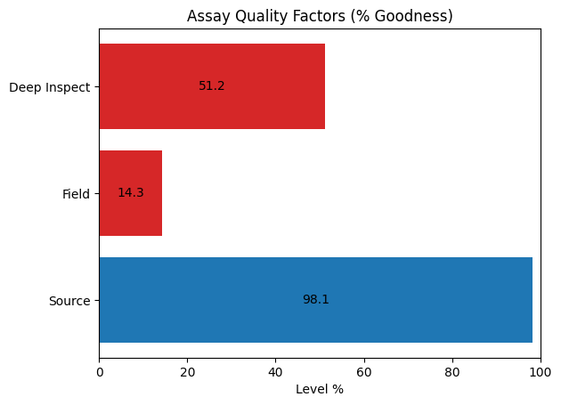

### Fields

Each field is listed with its datatype, whether it is a source or added enrichment field, defined format, and the computed quality factor, number of datatype errors found (dTErr), number of formatting errors found (fmtErr), and number of special characters found (spChar)

|  | title | datatype | enrich | format | quality | dTErr | fmtErr | spChar |
| --- | --- | --- | --- | --- | --- | --- | --- | --- |
| 0 | y2_statefips | int | false |  | 99.7 | 3 | 0 | 0 |
| 1 | y1_statefips | int | false |  | 99.9 | 1 | 0 | 0 |
| 2 | y1_state | string | false | case=upper,len=2,cutleft,padleft(x) | 90.7 | 0 | 8 | 0 |
| 3 | y1_state_name | string | false |  | 100.0 | 0 | 0 | 0 |
| 4 | n1 | int | false |  | 99.5 | 5 | 0 | 0 |
| 5 | n2 | int | false |  | 99.3 | 7 | 0 | 0 |
| 6 | AGI | int | false |  | 97.7 | 13 | 0 | 4 |
| 7 | useAGI | bool | true |  | NA | 0 | 0 | 0 |
| 8 | EndState | string | true |  | NA | 0 | 0 | 0 |

### DataType Errors

Table lists fields that have datatype errors and the number of instances (i.e source records)

```
Number Fields with DataType Errors= 5
```

|  | Count |
| --- | --- |
| n2 | 7 |
| n1 | 5 |
| y2_statefips | 3 |
| agi | 13 |
| y1_statefips | 1 |

```
number of examples per field: {'n2': 7, 'n1': 5, 'agi': 13, 'y2_statefips': 3, 'y1_statefips': 1}
```

### DataType Error Examples (max 25 per field)

Datatype error examples show the field's value in the record and the reason it is determined to be an error. The specific location in source file is shown to enable quick investigation and repair.

|  | title | datatype | value | reason | fileline | filename |
| --- | --- | --- | --- | --- | --- | --- |
| 0 | n2 | integer | x65647 | nonnumerics | 3 | IRSMigration_WithErrors_Hdr.csv |
| 1 | n2 | integer |  | empty | 5 | IRSMigration_WithErrors_Hdr.csv |
| 2 | n2 | integer |  | empty | 6 | IRSMigration_WithErrors_Hdr.csv |
| 3 | n2 | integer |  | empty | 7 | IRSMigration_WithErrors_Hdr.csv |
| 4 | n2 | integer |  | empty | 8 | IRSMigration_WithErrors_Hdr.csv |
| 5 | n2 | integer |  | empty | 9 | IRSMigration_WithErrors_Hdr.csv |
| 6 | n2 | integer | $2100 | nonnumerics | 18 | IRSMigration_WithErrors_Hdr.csv |
| 7 | n1 | integer |  | empty | 5 | IRSMigration_WithErrors_Hdr.csv |
| 8 | n1 | integer |  | empty | 6 | IRSMigration_WithErrors_Hdr.csv |
| 9 | n1 | integer |  | empty | 7 | IRSMigration_WithErrors_Hdr.csv |
| 10 | n1 | integer |  | empty | 8 | IRSMigration_WithErrors_Hdr.csv |
| 11 | n1 | integer |  | empty | 9 | IRSMigration_WithErrors_Hdr.csv |
| 12 | agi | integer |  | empty | 5 | IRSMigration_WithErrors_Hdr.csv |
| 13 | agi | integer |  | empty | 6 | IRSMigration_WithErrors_Hdr.csv |
| 14 | agi | integer |  | empty | 7 | IRSMigration_WithErrors_Hdr.csv |
| 15 | agi | integer |  | empty | 8 | IRSMigration_WithErrors_Hdr.csv |
| 16 | agi | integer |  | empty | 9 | IRSMigration_WithErrors_Hdr.csv |
| 17 | agi | integer | $48796 | nonnumerics | 19 | IRSMigration_WithErrors_Hdr.csv |
| 18 | agi | integer | (34582) | enclosed parens | 20 | IRSMigration_WithErrors_Hdr.csv |
| 19 | agi | integer | 27082ê | nonnumerics | 25 | IRSMigration_WithErrors_Hdr.csv |
| 20 | agi | integer | 24958‼ | nonnumerics | 26 | IRSMigration_WithErrors_Hdr.csv |
| 21 | agi | integer | 20884§ | nonnumerics | 27 | IRSMigration_WithErrors_Hdr.csv |
| 22 | agi | integer | 21821â–º | nonnumerics | 28 | IRSMigration_WithErrors_Hdr.csv |
| 23 | agi | integer | 9052.00 | integer has period char at index=4 | 37 | IRSMigration_WithErrors_Hdr.csv |
| 24 | agi | integer | 8578.00 | integer has period char at index=4 | 38 | IRSMigration_WithErrors_Hdr.csv |
| 25 | y2_statefips | integer | State | no numeric digits | 6 | IRSMigration_WithErrors_Hdr.csv |
| 26 | y2_statefips | integer | Non- | no numeric digits | 8 | IRSMigration_WithErrors_Hdr.csv |
| 27 | y2_statefips | integer | migrants | no numeric digits | 9 | IRSMigration_WithErrors_Hdr.csv |
| 28 | y1_statefips | integer |  | empty | 8 | IRSMigration_WithErrors_Hdr.csv |

### Format Errors

Table lists fields with detected format errors and the number of instances (i.e. records).

```
Number Fields with Format Errors= 1
```

|  | Count |
| --- | --- |
| y1_state | 8 |

### Format Error Examples (max 25 per field)

Table shows the field title, datatype, the field's value with error, reason for error, and the fileline number and source file.

```
number of examples per field: {'y1_state': 8}
```

|  | title | datatype | value | reason | fileline | filename |
| --- | --- | --- | --- | --- | --- | --- |
| 0 | y1_state | string | 95832 | length:5/2 | 6 | IRSMigration_WithErrors_Hdr.csv |
| 1 | y1_state | string |  | length:0/2 | 8 | IRSMigration_WithErrors_Hdr.csv |
| 2 | y1_state | string | 3579600 | length:7/2 | 9 | IRSMigration_WithErrors_Hdr.csv |
| 3 | y1_state | string | ny | case:upper | 20 | IRSMigration_WithErrors_Hdr.csv |
| 4 | y1_state | string | il | case:upper | 21 | IRSMigration_WithErrors_Hdr.csv |
| 5 | y1_state | string | oh | case:upper | 22 | IRSMigration_WithErrors_Hdr.csv |
| 6 | y1_state | string | sc | case:upper | 23 | IRSMigration_WithErrors_Hdr.csv |
| 7 | y1_state | string | mi | case:upper | 24 | IRSMigration_WithErrors_Hdr.csv |

### Special Character Examples (max 25 per special character)

Special characters are atypical or non-printable ASCII code characters, or Unicode characters above the standard code set. These can cause problems since many times they are either not displayed or appear the same as lower standard codes. This is a common occurrence in data systems supporting multiple languages. The table shows the character code found, the field found in, the value (which may not display completely depending on the special character), and the fileline and file of the record.

```
Number of Special Characters Discovered: 4
```

| char | field | value | fileline | filename |
| --- | --- | --- | --- | --- |
| ascii_234 | agi | 27082ê | 25 | IRSMigration_WithErrors_Hdr.csv |
| unicode_8252 | agi | 24958‼ | 26 | IRSMigration_WithErrors_Hdr.csv |
| ascii_167 | agi | 20884§ | 27 | IRSMigration_WithErrors_Hdr.csv |
| unicode_9658 | agi | 21821â–º | 28 | IRSMigration_WithErrors_Hdr.csv |

## DataTypes Per Field

Datatypes are int (integer), real, date, bool, string or empty field. This table displays the distribution detected for each field. Note that a field may be numeric and defined as real but have integer values which may be acceptable. However, VerityRefiner detects this as an error if the field is defined to be real since formally it should have a decimal part.

|  | title | datatype | int | real | date | bool | string | empty |
| --- | --- | --- | --- | --- | --- | --- | --- | --- |
| 0 | y2_statefips | int | 1000 | 0 | 0 | 0 | 3 | 0 |
| 1 | y1_statefips | int | 1002 | 0 | 0 | 0 | 0 | 1 |
| 2 | y1_state | string | 2 | 0 | 0 | 0 | 1000 | 1 |
| 3 | y1_state_name | string | 2 | 0 | 0 | 0 | 1000 | 1 |
| 4 | n1 | int | 998 | 0 | 0 | 0 | 0 | 5 |
| 5 | n2 | int | 996 | 0 | 0 | 0 | 2 | 5 |

The following charts and graphs display distributions depending on the field datatype.

- int and real: number of decimal places if found
- string: value lengths, and capitalization cases

The string value length is a good way to quickly see if actual values agree with expected values. In many systems, it was common to reuse data fields for differently coded semantics and for this to not be described in documentation. Hence, over time the fact that the value range is overloaded is forgotten, is not documented and causes significant errors downstream of the data system.

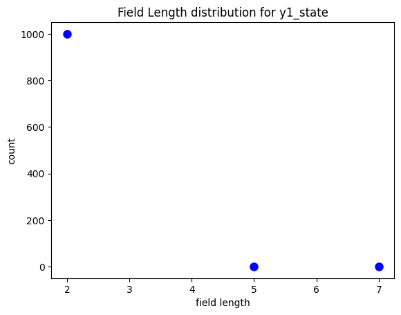

```
String Cases for y1_state
```

| case | count |
| --- | --- |
| upper | 995 |
| lower | 5 |
| mixed | 0 |
| none | 0 |

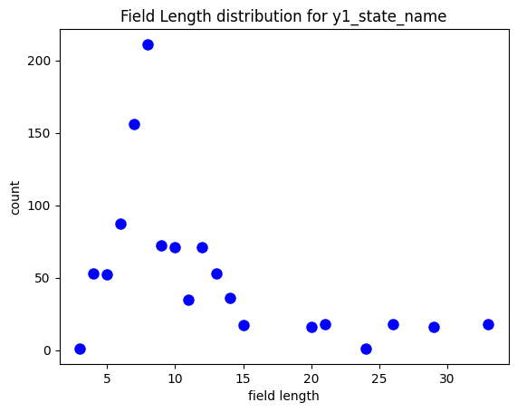

```
String Cases for y1_state_name
```

| case | count |
| --- | --- |
| upper | 1 |
| lower | 0 |
| mixed | 999 |
| none | 0 |

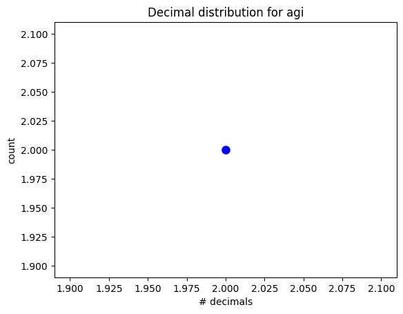

## Unique Values

Unique value distributions show the value range of fields. The table displays the top fifty most prevalent values for each field and the detected datatype of these values. A valuable aspect of how VerityRefiner presents actual value spaces is to separately capture the lowest occuring values and to display them. This showcases edge cases that are usually lost within the much larger set of prevalent values. For each field below, a table displays the top 50 occuring unique values and then a table displaying the bottom 25 least occuring values.

```
Field: Y2_STATEFIPS
Top 50 Unique Values
```

|  | value | count | datatype |
| --- | --- | --- | --- |
| 0 | 09 | 56 | int |
| 1 | 12 | 56 | int |
| 2 | 02 | 56 | int |
| 3 | 04 | 56 | int |
| 4 | 19 | 56 | int |
| 5 | 18 | 56 | int |
| 6 | 17 | 56 | int |
| 7 | 16 | 56 | int |
| 8 | 15 | 56 | int |
| 9 | 13 | 56 | int |
| 10 | 10 | 56 | int |
| 11 | 20 | 56 | int |
| 12 | 08 | 56 | int |
| 13 | 06 | 56 | int |
| 14 | 05 | 56 | int |
| 15 | 01 | 55 | int |
| 16 | 11 | 55 | int |
| 17 | 21 | 49 | int |
| 18 | migrants | 1 | string |
| 19 | non- | 1 | string |
| 20 | 1 | 1 | int |
| 21 | state | 1 | string |

```
Bottom 25 Unique Values
```

|  | value | count | datatype |
| --- | --- | --- | --- |
| 0 | state | 1 | string |
| 1 | migrants | 1 | string |
| 2 | 1 | 1 | int |
| 3 | non- | 1 | string |
| 4 | 21 | 49 | int |
| 5 | 11 | 55 | int |
| 6 | 01 | 55 | int |
| 7 | 04 | 56 | int |
| 8 | 19 | 56 | int |
| 9 | 18 | 56 | int |
| 10 | 17 | 56 | int |
| 11 | 16 | 56 | int |
| 12 | 15 | 56 | int |
| 13 | 20 | 56 | int |
| 14 | 12 | 56 | int |
| 15 | 10 | 56 | int |
| 16 | 02 | 56 | int |
| 17 | 08 | 56 | int |
| 18 | 06 | 56 | int |
| 19 | 05 | 56 | int |
| 20 | 13 | 56 | int |
| 21 | 09 | 56 | int |

```
Field: Y1_STATEFIPS
Top 50 Unique Values
```

|  | value | count | datatype |
| --- | --- | --- | --- |
| 0 | 97 | 35 | int |
| 1 | 05 | 18 | int |
| 2 | 51 | 18 | int |
| 3 | 53 | 18 | int |
| 4 | 42 | 18 | int |
| 5 | 18 | 18 | int |
| 6 | 29 | 18 | int |
| 7 | 08 | 18 | int |
| 8 | 21 | 18 | int |
| 9 | 26 | 18 | int |
| 10 | 45 | 18 | int |
| 11 | 39 | 18 | int |
| 12 | 17 | 18 | int |
| 13 | 36 | 18 | int |
| 14 | 57 | 18 | int |
| 15 | 40 | 18 | int |
| 16 | 22 | 18 | int |
| 17 | 37 | 18 | int |
| 18 | 06 | 18 | int |
| 19 | 28 | 18 | int |
| 20 | 47 | 18 | int |
| 21 | 48 | 18 | int |
| 22 | 12 | 18 | int |
| 23 | 13 | 18 | int |
| 24 | 01 | 18 | int |
| 25 | 98 | 18 | int |
| 26 | 24 | 18 | int |
| 27 | 96 | 18 | int |
| 28 | 04 | 18 | int |
| 29 | 49 | 18 | int |
| 30 | 09 | 18 | int |
| 31 | 33 | 18 | int |
| 32 | 46 | 18 | int |
| 33 | 23 | 18 | int |
| 34 | 56 | 18 | int |
| 35 | 31 | 18 | int |
| 36 | 32 | 18 | int |
| 37 | 19 | 18 | int |
| 38 | 35 | 18 | int |
| 39 | 02 | 18 | int |
| 40 | 15 | 18 | int |
| 41 | 54 | 18 | int |
| 42 | 25 | 18 | int |
| 43 | 34 | 18 | int |
| 44 | 20 | 18 | int |
| 45 | 55 | 18 | int |
| 46 | 27 | 18 | int |
| 47 | 41 | 18 | int |
| 48 | 10 | 17 | int |
| 49 | 11 | 17 | int |

```
Bottom 25 Unique Values
```

|  | value | count | datatype |
| --- | --- | --- | --- |
| 0 | 46630 | 1 | int |
| 1 |  | 1 | -unk- |
| 2 | 1598458 | 1 | int |
| 3 | 50 | 17 | int |
| 4 | 44 | 17 | int |
| 5 | 16 | 17 | int |
| 6 | 30 | 17 | int |
| 7 | 38 | 17 | int |
| 8 | 11 | 17 | int |
| 9 | 10 | 17 | int |
| 10 | 25 | 18 | int |
| 11 | 54 | 18 | int |
| 12 | 15 | 18 | int |
| 13 | 09 | 18 | int |
| 14 | 35 | 18 | int |
| 15 | 19 | 18 | int |
| 16 | 23 | 18 | int |
| 17 | 49 | 18 | int |
| 18 | 31 | 18 | int |
| 19 | 56 | 18 | int |
| 20 | 34 | 18 | int |
| 21 | 46 | 18 | int |
| 22 | 33 | 18 | int |
| 23 | 02 | 18 | int |
| 24 | 20 | 18 | int |

```
Field: Y1_STATE
Top 50 Unique Values
```

|  | value | count | datatype |
| --- | --- | --- | --- |
| 0 | al | 22 | string |
| 1 | il | 22 | string |
| 2 | ak | 22 | string |
| 3 | ar | 22 | string |
| 4 | co | 22 | string |
| 5 | az | 22 | string |
| 6 | ks | 22 | string |
| 7 | ga | 22 | string |
| 8 | ky | 22 | string |
| 9 | ct | 22 | string |
| 10 | in | 22 | string |
| 11 | ca | 22 | string |
| 12 | ia | 22 | string |
| 13 | fl | 22 | string |
| 14 | hi | 22 | string |
| 15 | id | 21 | string |
| 16 | de | 21 | string |
| 17 | dc | 20 | string |
| 18 | ms | 18 | string |
| 19 | ny | 18 | string |
| 20 | mo | 18 | string |
| 21 | tx | 18 | string |
| 22 | tn | 18 | string |
| 23 | mi | 18 | string |
| 24 | nc | 18 | string |
| 25 | la | 18 | string |
| 26 | oh | 18 | string |
| 27 | va | 18 | string |
| 28 | me | 18 | string |
| 29 | md | 18 | string |
| 30 | fr | 18 | string |
| 31 | sc | 18 | string |
| 32 | ok | 18 | string |
| 33 | wa | 18 | string |
| 34 | wv | 18 | string |
| 35 | nh | 18 | string |
| 36 | sd | 18 | string |
| 37 | ut | 18 | string |
| 38 | wy | 18 | string |
| 39 | pa | 18 | string |
| 40 | or | 18 | string |
| 41 | mn | 18 | string |
| 42 | nm | 18 | string |
| 43 | nv | 18 | string |
| 44 | ma | 18 | string |
| 45 | wi | 18 | string |
| 46 | nj | 18 | string |
| 47 | ne | 18 | string |
| 48 | mt | 17 | string |
| 49 | nd | 17 | string |

```
Bottom 25 Unique Values
```

|  | value | count | datatype |
| --- | --- | --- | --- |
| 0 | 95832 | 1 | int |
| 1 |  | 1 | -unk- |
| 2 | 3579600 | 1 | int |
| 3 | vt | 17 | string |
| 4 | ri | 17 | string |
| 5 | nd | 17 | string |
| 6 | mt | 17 | string |
| 7 | ma | 18 | string |
| 8 | nv | 18 | string |
| 9 | nm | 18 | string |
| 10 | mn | 18 | string |
| 11 | or | 18 | string |
| 12 | pa | 18 | string |
| 13 | md | 18 | string |
| 14 | wy | 18 | string |
| 15 | nh | 18 | string |
| 16 | sd | 18 | string |
| 17 | wi | 18 | string |
| 18 | wv | 18 | string |
| 19 | wa | 18 | string |
| 20 | ok | 18 | string |
| 21 | sc | 18 | string |
| 22 | fr | 18 | string |
| 23 | me | 18 | string |
| 24 | nj | 18 | string |

```
Field: Y1_STATE_NAME
Top 50 Unique Values
```

|  | value | count | datatype |
| --- | --- | --- | --- |
| 0 | wisconsin | 18 | string |
| 1 | south carolina | 18 | string |
| 2 | utah | 18 | string |
| 3 | ohio | 18 | string |
| 4 | west virginia | 18 | string |
| 5 | nevada | 18 | string |
| 6 | new jersey | 18 | string |
| 7 | michigan | 18 | string |
| 8 | washington | 18 | string |
| 9 | pennsylvania | 18 | string |
| 10 | missouri | 18 | string |
| 11 | minnesota | 18 | string |
| 12 | oklahoma | 18 | string |
| 13 | nebraska | 18 | string |
| 14 | oregon | 18 | string |
| 15 | maine | 18 | string |
| 16 | louisiana | 18 | string |
| 17 | wyoming | 18 | string |
| 18 | south dakota | 18 | string |
| 19 | tennessee | 18 | string |
| 20 | new york | 18 | string |
| 21 | north carolina | 18 | string |
| 22 | mississippi | 18 | string |
| 23 | foreign | 18 | string |
| 24 | virginia | 18 | string |
| 25 | texas | 18 | string |
| 26 | maryland | 18 | string |
| 27 | new hampshire | 18 | string |
| 28 | new mexico | 17 | string |
| 29 | alaska | 17 | string |
| 30 | florida | 17 | string |
| 31 | connecticut | 17 | string |
| 32 | georgia | 17 | string |
| 33 | iowa | 17 | string |
| 34 | illinois | 17 | string |
| 35 | alabama | 17 | string |
| 36 | montana | 17 | string |
| 37 | north dakota | 17 | string |
| 38 | massachusetts | 17 | string |
| 39 | kentucky | 17 | string |
| 40 | vermont | 17 | string |
| 41 | indiana | 17 | string |
| 42 | kansas | 17 | string |
| 43 | arizona | 17 | string |
| 44 | arkansas | 17 | string |
| 45 | california | 17 | string |
| 46 | hawaii | 17 | string |
| 47 | colorado | 17 | string |
| 48 | rhode island | 17 | string |
| 49 | delaware | 16 | string |

```
Bottom 25 Unique Values
```

|  | value | count | datatype |
| --- | --- | --- | --- |
| 0 | az non-migrants | 1 | string |
| 1 | il total migration-foreign | 1 | string |
| 2 | il total migration-same state | 1 | string |
| 3 | il non-migrants | 1 | string |
| 4 | ar total migration-foreign | 1 | string |
| 5 | hi total migration-us | 1 | string |
| 6 | in total migration-us and foreign | 1 | string |
| 7 | ia total migration-us and foreign | 1 | string |
| 8 | ks total migration-foreign | 1 | string |
| 9 | ia total migration-us | 1 | string |
| 10 | ia total migration-foreign | 1 | string |
| 11 | il total migration-us | 1 | string |
| 12 | ia total migration-same state | 1 | string |
| 13 | in total migration-same state | 1 | string |
| 14 | ks total migration-us and foreign | 1 | string |
| 15 | ks total migration-same state | 1 | string |
| 16 | in total migration-us | 1 | string |
| 17 | ks non-migrants | 1 | string |
| 18 | ky total migration-us and foreign | 1 | string |
| 19 | ky total migration-us | 1 | string |
| 20 | ky total migration-foreign | 1 | string |
| 21 | ks total migration-us | 1 | string |
| 22 | in total migration-foreign | 1 | string |
| 23 | ia non-migrants | 1 | string |
| 24 | il total migration-us and foreign | 1 | string |

```
Field: N1
Top 50 Unique Values
```

|  | value | count | datatype |
| --- | --- | --- | --- |
| 0 | -1 | 13 | int |
| 1 | 97 | 8 | int |
| 2 | 59 | 6 | int |
| 3 | 30 | 5 | int |
| 4 | 27 | 5 | int |
| 5 | 76 | 5 | int |
| 6 | 124 | 5 | int |
| 7 | 52 | 5 | int |
| 8 | 49 | 5 | int |
| 9 | 130 | 5 | int |
| 10 |  | 5 | string |
| 11 | 29 | 5 | int |
| 12 | 99 | 4 | int |
| 13 | 14 | 4 | int |
| 14 | 33 | 4 | int |
| 15 | 440 | 4 | int |
| 16 | 25 | 4 | int |
| 17 | 65 | 4 | int |
| 18 | 618 | 4 | int |
| 19 | 43 | 4 | int |
| 20 | 42 | 4 | int |
| 21 | 117 | 4 | int |
| 22 | 100 | 4 | int |
| 23 | 48 | 4 | int |
| 24 | 365 | 4 | int |
| 25 | 105 | 4 | int |
| 26 | 203 | 3 | int |
| 27 | 151 | 3 | int |
| 28 | 126 | 3 | int |
| 29 | 21 | 3 | int |
| 30 | 367 | 3 | int |
| 31 | 138 | 3 | int |
| 32 | 28 | 3 | int |
| 33 | 51 | 3 | int |
| 34 | 128 | 3 | int |
| 35 | 180 | 3 | int |
| 36 | 94 | 3 | int |
| 37 | 111 | 3 | int |
| 38 | 226 | 3 | int |
| 39 | 58 | 3 | int |
| 40 | 39 | 3 | int |
| 41 | 34 | 3 | int |
| 42 | 23 | 3 | int |
| 43 | 127 | 3 | int |
| 44 | 297 | 3 | int |
| 45 | 549 | 3 | int |
| 46 | 80 | 3 | int |
| 47 | 313 | 3 | int |
| 48 | 159 | 3 | int |
| 49 | 144 | 3 | int |

```
Bottom 25 Unique Values
```

|  | value | count | datatype |
| --- | --- | --- | --- |
| 0 | 2243 | 1 | int |
| 1 | 4889 | 1 | int |
| 2 | 5405 | 1 | int |
| 3 | 250 | 1 | int |
| 4 | 45828 | 1 | int |
| 5 | 230 | 1 | int |
| 6 | 228 | 1 | int |
| 7 | 206 | 1 | int |
| 8 | 2465 | 1 | int |
| 9 | 192 | 1 | int |
| 10 | 68 | 1 | int |
| 11 | 808 | 1 | int |
| 12 | 31361 | 1 | int |
| 13 | 1486245 | 1 | int |
| 14 | 5747 | 1 | int |
| 15 | 4617 | 1 | int |
| 16 | 3809 | 1 | int |
| 17 | 190 | 1 | int |
| 18 | 155 | 1 | int |
| 19 | 168 | 1 | int |
| 20 | 174 | 1 | int |
| 21 | 4857323 | 1 | int |
| 22 | 6788 | 1 | int |
| 23 | 30713 | 1 | int |
| 24 | 835 | 1 | int |

```
Field: N2
Top 50 Unique Values
```

|  | value | count | datatype |
| --- | --- | --- | --- |
| 0 | -1 | 13 | int |
| 1 | 57 | 5 | int |
| 2 | 33 | 5 | int |
| 3 |  | 5 | string |
| 4 | 207 | 4 | int |
| 5 | 172 | 4 | int |
| 6 | 66 | 4 | int |
| 7 | 272 | 3 | int |
| 8 | 60 | 3 | int |
| 9 | 323 | 3 | int |
| 10 | 64 | 3 | int |
| 11 | 269 | 3 | int |
| 12 | 170 | 3 | int |
| 13 | 127 | 3 | int |
| 14 | 205 | 3 | int |
| 15 | 439 | 3 | int |
| 16 | 61 | 3 | int |
| 17 | 150 | 3 | int |
| 18 | 100 | 3 | int |
| 19 | 89 | 3 | int |
| 20 | 222 | 3 | int |
| 21 | 68 | 3 | int |
| 22 | 1026 | 3 | int |
| 23 | 46 | 3 | int |
| 24 | 235 | 3 | int |
| 25 | 76 | 3 | int |
| 26 | 704 | 3 | int |
| 27 | 231 | 3 | int |
| 28 | 111 | 3 | int |
| 29 | 131 | 3 | int |
| 30 | 691 | 3 | int |
| 31 | 796 | 2 | int |
| 32 | 333 | 2 | int |
| 33 | 3601 | 2 | int |
| 34 | 28 | 2 | int |
| 35 | 972 | 2 | int |
| 36 | 1349 | 2 | int |
| 37 | 496 | 2 | int |
| 38 | 749 | 2 | int |
| 39 | 1500 | 2 | int |
| 40 | 193 | 2 | int |
| 41 | 794 | 2 | int |
| 42 | 21 | 2 | int |
| 43 | 194 | 2 | int |
| 44 | 1476 | 2 | int |
| 45 | 94 | 2 | int |
| 46 | 36 | 2 | int |
| 47 | 71 | 2 | int |
| 48 | 357 | 2 | int |
| 49 | 93 | 2 | int |

```
Bottom 25 Unique Values
```

|  | value | count | datatype |
| --- | --- | --- | --- |
| 0 | 1291 | 1 | int |
| 1 | 3260782 | 1 | int |
| 2 | 4505 | 1 | int |
| 3 | 6329 | 1 | int |
| 4 | 7030 | 1 | int |
| 5 | 581 | 1 | int |
| 6 | 574 | 1 | int |
| 7 | 464 | 1 | int |
| 8 | 452 | 1 | int |
| 9 | 463 | 1 | int |
| 10 | 346 | 1 | int |
| 11 | 2591 | 1 | int |
| 12 | 325 | 1 | int |
| 13 | 347 | 1 | int |
| 14 | 38581 | 1 | int |
| 15 | 335 | 1 | int |
| 16 | 137 | 1 | int |
| 17 | 130 | 1 | int |
| 18 | 107 | 1 | int |
| 19 | 38 | 1 | int |
| 20 | 60365 | 1 | int |
| 21 | 58863 | 1 | int |
| 22 | 89677 | 1 | int |
| 23 | 350 | 1 | int |
| 24 | 8330 | 1 | int |

[output not shown]

## CoValues

CoValues are joint field value distributions for either two or three fields. The table displays the top fifty most prevalent value combinations for each CoValue group.

```
CoValue: Y1_STATE:Y1_STATE_NAME
```

|  | value | count |
| --- | --- | --- |
| 0 | wi:wisconsin | 18 |
| 1 | nj:new jersey | 18 |
| 2 | wa:washington | 18 |
| 3 | pa:pennsylvania | 18 |
| 4 | mo:missouri | 18 |
| 5 | or:oregon | 18 |
| 6 | mn:minnesota | 18 |
| 7 | ok:oklahoma | 18 |
| 8 | ne:nebraska | 18 |
| 9 | sc:south carolina | 18 |
| 10 | me:maine | 18 |
| 11 | sd:south dakota | 18 |
| 12 | nh:new hampshire | 18 |
| 13 | md:maryland | 18 |
| 14 | tx:texas | 18 |
| 15 | va:virginia | 18 |
| 16 | fr:foreign | 18 |
| 17 | la:louisiana | 18 |
| 18 | nc:north carolina | 18 |
| 19 | ny:new york | 18 |
| 20 | tn:tennessee | 18 |
| 21 | ms:mississippi | 18 |
| 22 | wy:wyoming | 18 |
| 23 | mi:michigan | 18 |
| 24 | nv:nevada | 18 |
| 25 | oh:ohio | 18 |
| 26 | ut:utah | 18 |
| 27 | wv:west virginia | 18 |
| 28 | ak:alaska | 17 |
| 29 | nm:new mexico | 17 |
| 30 | fl:florida | 17 |
| 31 | ct:connecticut | 17 |
| 32 | ga:georgia | 17 |
| 33 | ia:iowa | 17 |
| 34 | il:illinois | 17 |
| 35 | al:alabama | 17 |
| 36 | mt:montana | 17 |
| 37 | nd:north dakota | 17 |
| 38 | ma:massachusetts | 17 |
| 39 | in:indiana | 17 |
| 40 | vt:vermont | 17 |
| 41 | ky:kentucky | 17 |
| 42 | ks:kansas | 17 |
| 43 | az:arizona | 17 |
| 44 | ar:arkansas | 17 |
| 45 | ca:california | 17 |
| 46 | hi:hawaii | 17 |
| 47 | co:colorado | 17 |
| 48 | ri:rhode island | 17 |
| 49 | dc:district of columbia | 16 |

```
Low CoValues: Y1_STATE:Y1_STATE_NAME
```

|  | value | count |
| --- | --- | --- |
| 0 | az:az non-migrants | 1 |
| 1 | il:il total migration-foreign | 1 |
| 2 | il:il total migration-same state | 1 |
| 3 | il:il non-migrants | 1 |
| 4 | ar:ar total migration-foreign | 1 |
| 5 | hi:hi total migration-us | 1 |
| 6 | in:in total migration-us and foreign | 1 |
| 7 | ia:ia total migration-us and foreign | 1 |
| 8 | ks:ks total migration-foreign | 1 |
| 9 | ia:ia total migration-us | 1 |
| 10 | ia:ia total migration-foreign | 1 |
| 11 | il:il total migration-us | 1 |
| 12 | ia:ia total migration-same state | 1 |
| 13 | in:in total migration-same state | 1 |
| 14 | ks:ks total migration-us and foreign | 1 |
| 15 | ks:ks total migration-same state | 1 |
| 16 | in:in total migration-us | 1 |
| 17 | ks:ks non-migrants | 1 |
| 18 | ky:ky total migration-us and foreign | 1 |
| 19 | ky:ky total migration-us | 1 |
| 20 | ky:ky total migration-foreign | 1 |
| 21 | ks:ks total migration-us | 1 |
| 22 | in:in total migration-foreign | 1 |
| 23 | ia:ia non-migrants | 1 |
| 24 | il:il total migration-us and foreign | 1 |